# Waal Intrinsic Variables and Parental Care Coordination Model Script

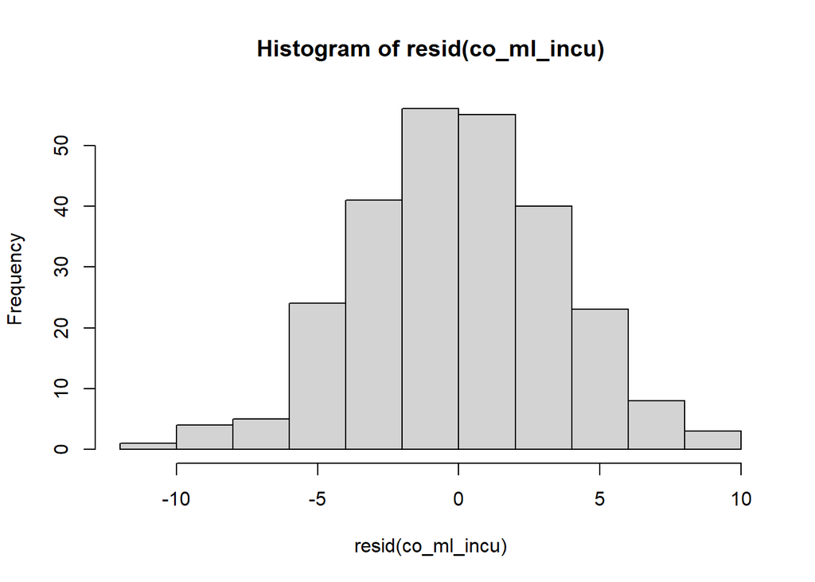

```r
hist(resid(co_ml_incu))
```

Step 3: A model set is created from the global model. This creates all possible versions of the model to establish the best fit. As the focal bird age and its quadratic equivalent (`age_sc` and `age_sq_sc`) must be retained or discarded together, additional code is added to ensure this is reflected in the model set. Similarly, the partner bird age variable and its quadratic equivalent(`p_age_sc` and `p_age_sq_sc`) receive the same treatment.This portion of the code may take several hours to run.

```r
# dredging to create model set
# linking age variables with their quadratic counterpart so either both or neither are retained
dr_cmin<-dredge(co_ml_incu, subset = (dc(age_sc, age_sq_sc) &&
                                        dc(p_age_sc, p_age_sq_sc) &&
                                        dc(age_sq_sc, age_sc) &&
                                        dc(p_age_sq_sc, p_age_sc)))
dr_cmin # view full model list
```

Step 4: The models are ranked according to AIC. Next, those models with delta < 2 are subsetted. Another piece of code indicates how many models have been retained following this action.

```r
sub_m1_incu<-subset(dr_cmin, delta<2) ##subsets models delta <2
sub_m1_incu # view subsetted models
```

```
## Global model call: lmer(formula = no_hours_sqrt ~ sex + pers_sc + p_pers_sc + age_sc +
##     age_sq_sc + p_age_sc + p_age_sq_sc + num_days_sc + new_part +
##     ppb_ave_diff_sc + age_sc:pers_sc + age_sq_sc:pers_sc + age_sc:ppb_ave_diff_sc +
##     age_sq_sc:ppb_ave_diff_sc + pers_sc:ppb_ave_diff_sc + new_part:ppb_ave_diff_sc +
##     p_age_sc:p_pers_sc + p_age_sq_sc:p_pers_sc + p_age_sc:ppb_ave_diff_sc +
##     p_age_sq_sc:ppb_ave_diff_sc + p_pers_sc:ppb_ave_diff_sc +
##     (1 | cycle) + (1 + ppb_ave_diff_sc | cycle_pair), data = incu_new2,
##     REML = FALSE, control = lmerControl(optimizer = "optimx",
##         optCtrl = list(method = "nlminb")), na.action = na.fail)
## ---
## Model selection table
##         (Int) num_dys_sc p_age_sc p_age_sq_sc p_prs_sc  prs_sc ppb_ave_dff_sc
## 841     11.23      1.652                       -0.5041                 0.4809
## 132089  11.33      1.647    5.719      -5.652  -0.7965 -0.6592         0.4773
## 1017    11.29      1.654    4.803      -4.772  -0.8627 -0.6124         0.4739
```

[output cut: 71 more lines]

```r
no_m1_incu<-dim(as.data.frame(sub_m1_incu))[1] # how many models are in the subsetted model set
no_m1_incu # number of models retained
```

```
## [1] 23
```

Step 5: The nested models are removed (see methods for justification).

```r
nest_m1_incu <- subset(sub_m1_incu, !nested(.)) # removes nested models
nest_m1_incu # view retained models
```

```
## Global model call: lmer(formula = no_hours_sqrt ~ sex + pers_sc + p_pers_sc + age_sc +
##     age_sq_sc + p_age_sc + p_age_sq_sc + num_days_sc + new_part +
##     ppb_ave_diff_sc + age_sc:pers_sc + age_sq_sc:pers_sc + age_sc:ppb_ave_diff_sc +
##     age_sq_sc:ppb_ave_diff_sc + pers_sc:ppb_ave_diff_sc + new_part:ppb_ave_diff_sc +
##     p_age_sc:p_pers_sc + p_age_sq_sc:p_pers_sc + p_age_sc:ppb_ave_diff_sc +
##     p_age_sq_sc:ppb_ave_diff_sc + p_pers_sc:ppb_ave_diff_sc +
##     (1 | cycle) + (1 + ppb_ave_diff_sc | cycle_pair), data = incu_new2,
##     REML = FALSE, control = lmerControl(optimizer = "optimx",
##         optCtrl = list(method = "nlminb")), na.action = na.fail)
## ---
## Model selection table
##     (Int) num_dys_sc p_age_sc p_age_sq_sc p_prs_sc ppb_ave_dff_sc sex df
## 841 11.23      1.652                       -0.5041         0.4809   + 10
## 825 11.35      1.557    4.739      -4.741                  0.5000   + 11
## 585 11.16      1.845                       -0.5096                  +  9
## 777 11.41      1.622                                       0.4892   +  9
## 569 11.28      1.752    4.618      -4.614                           + 10
## 521 11.34      1.816                                                +  8
##       logLik   AICc delta weight
## 841 -730.731 1482.3  0.00  0.270
## 825 -730.055 1483.2  0.83  0.179
## 585 -732.228 1483.2  0.83  0.178
## 777 -732.322 1483.4  1.02  0.163
## 569 -731.670 1484.2  1.88  0.106
## 521 -733.836 1484.2  1.90  0.105
## Models ranked by AICc(x)
## Random terms (all models):
## '1 | cycle', '1 + ppb_ave_diff_sc | cycle_pair'
```

```r
no_m12_incu<-dim(as.data.frame(nest_m1_incu))[1] # how many models retained when nested models removed
no_m12_incu # number of models
```

```
## [1] 6
```

Step 6: The remaining then undergo model averaging to create a final coefficient table.

```r
modavm1_incu<-model.avg(nest_m1_incu, delta<2, fit = TRUE) # model averaging
modavm1_incu
```

```
##
## Call:
## model.avg(object = get.models(object = nest_m1_incu, subset = delta <
##     2))
##
## Component models:
## '1456'  '12356' '146'   '156'   '1236'  '16'
##
## Coefficients:
##        (Intercept) num_days_sc  p_pers_sc ppb_ave_diff_sc   sexMale p_age_sc
## full      11.28571    1.692215 -0.2271670       0.2987677 -1.394078 1.334451
## subset    11.28571    1.692215 -0.5062667       0.4886737 -1.394078 4.694464
##        p_age_sq_sc
## full     -1.334284
## subset   -4.693879
```

```r
Weights(modavm1_incu)
```

```
## AICc model weights
## [1] 0.270 0.179 0.178 0.163 0.106 0.105
```

```r
tablem1a_incu<-coefTable(modavm1_incu, full=TRUE)
tablem1a_incu # final coefficient table
```

```
##                 Estimate Std. Error
## (Intercept)     11.28571     0.4749
## num_days_sc      1.69222     0.3174
## p_pers_sc       -0.22717     0.3151
## ppb_ave_diff_sc  0.29877     0.3110
## sexMale         -1.39408     0.5243
## p_age_sc         1.33445     2.4247
## p_age_sq_sc     -1.33428     2.4270
```

The variables listed immediately above are highlighted as having the most significant impact on the response variable following model averaging.

### Brooding Models

The process is then repeated in full with the brooding subset.

Step 1: A linear model is created for initial analysis.

```r
#bolker suggested linear model BROODING
lin_model <- lm(no_hours_sqrt ~
                  sex +
                  pers_sc +
                  p_pers_sc+
                  age_sc +
                  age_sq_sc +
                  p_age_sc+
                  p_age_sq_sc+
                  num_days_sc+
                  new_part+
                  ppb_ave_diff_sc+
                  age_sc:pers_sc+
                  age_sq_sc:pers_sc+
                  age_sc:ppb_ave_diff_sc+
                  age_sq_sc:ppb_ave_diff_sc+
                  pers_sc:ppb_ave_diff_sc+
                  new_part:ppb_ave_diff_sc+
                  p_age_sc:p_pers_sc+
                  p_age_sq_sc:p_pers_sc+
                  p_age_sc:ppb_ave_diff_sc+
                  p_age_sq_sc:ppb_ave_diff_sc+
                  p_pers_sc:ppb_ave_diff_sc,
                  data = brood_new2)
summary(lin_model)
```

```
##
## Call:
## lm(formula = no_hours_sqrt ~ sex + pers_sc + p_pers_sc + age_sc +
##     age_sq_sc + p_age_sc + p_age_sq_sc + num_days_sc + new_part +
##     ppb_ave_diff_sc + age_sc:pers_sc + age_sq_sc:pers_sc + age_sc:ppb_ave_diff_sc +
##     age_sq_sc:ppb_ave_diff_sc + pers_sc:ppb_ave_diff_sc + new_part:ppb_ave_diff_sc +
##     p_age_sc:p_pers_sc + p_age_sq_sc:p_pers_sc + p_age_sc:ppb_ave_diff_sc +
##     p_age_sq_sc:ppb_ave_diff_sc + p_pers_sc:ppb_ave_diff_sc,
##     data = brood_new2)
##
## Residuals:
##     Min      1Q  Median      3Q     Max
## -7.2014 -1.1301  0.0961  1.1237  9.4445
##
## Coefficients:
##                             Estimate Std. Error t value Pr(>|t|)
## (Intercept)                  7.93842    0.12707  62.474  < 2e-16 ***
## sexMale                     -0.37778    0.18225  -2.073  0.03862 *
## pers_sc                     -0.30927    0.09232  -3.350  0.00086 ***
## p_pers_sc                   -0.28549    0.09214  -3.098  0.00204 **
## age_sc                       0.10310    0.56986   0.181  0.85649
## age_sq_sc                   -0.16641    0.55579  -0.299  0.76473
## p_age_sc                     0.24973    0.58020   0.430  0.66705
## p_age_sq_sc                 -0.05367    0.56485  -0.095  0.92433
## num_days_sc                 -0.21966    0.08287  -2.651  0.00825 **
## new_part1                    0.70365    0.27370   2.571  0.01039 *
## ppb_ave_diff_sc              0.12519    0.09028   1.387  0.16605
## pers_sc:age_sc              -0.24356    0.56583  -0.430  0.66703
## pers_sc:age_sq_sc            0.02843    0.56018   0.051  0.95955
## age_sc:ppb_ave_diff_sc       0.52713    0.62288   0.846  0.39774
## age_sq_sc:ppb_ave_diff_sc   -0.33976    0.60585  -0.561  0.57515
## pers_sc:ppb_ave_diff_sc     -0.16570    0.09607  -1.725  0.08507 .
## new_part1:ppb_ave_diff_sc    0.32294    0.27094   1.192  0.23377
## p_pers_sc:p_age_sc           1.10187    0.56729   1.942  0.05257 .
## p_pers_sc:p_age_sq_sc       -1.13014    0.55863  -2.023  0.04352 *
## p_age_sc:ppb_ave_diff_sc     0.06407    0.62105   0.103  0.91787
## p_age_sq_sc:ppb_ave_diff_sc -0.25638    0.60609  -0.423  0.67244
## p_pers_sc:ppb_ave_diff_sc    0.08774    0.09290   0.944  0.34534
## ---
## Signif. codes:  0 '***' 0.001 '**' 0.01 '*' 0.05 '.' 0.1 ' ' 1
##
## Residual standard error: 1.994 on 589 degrees of freedom
## Multiple R-squared:  0.09131,    Adjusted R-squared:  0.05891
## F-statistic: 2.818 on 21 and 589 DF,  p-value: 3.25e-05
```

Step 2: The global model is created.

```r
co_ml_brood<- lmer(no_hours_sqrt ~
                     sex +
                     pers_sc +
                     p_pers_sc+
                     age_sc +
                     age_sq_sc +
                     p_age_sc+
                     p_age_sq_sc+
                     num_days_sc+
                     new_part+
                     ppb_ave_diff_sc+
                     age_sc:pers_sc+
                     age_sq_sc:pers_sc+
                     age_sc:ppb_ave_diff_sc+
                     age_sq_sc:ppb_ave_diff_sc+
                     pers_sc:ppb_ave_diff_sc+
                     new_part:ppb_ave_diff_sc+
                     p_age_sc:p_pers_sc+
                     p_age_sq_sc:p_pers_sc+
                     p_age_sc:ppb_ave_diff_sc+
                     p_age_sq_sc:ppb_ave_diff_sc+
                     p_pers_sc:ppb_ave_diff_sc+
                     (1|cycle) + (1+ppb_ave_diff_sc|cycle_pair),
                   data = brood_new2, na.action=na.fail, REML=FALSE,
                   control=lmerControl (optimizer="optimx",optCtrl=list(method='nlminb')))

summary(co_ml_brood)
```

```
## Linear mixed model fit by maximum likelihood  ['lmerMod']
## Formula: no_hours_sqrt ~ sex + pers_sc + p_pers_sc + age_sc + age_sq_sc +
##     p_age_sc + p_age_sq_sc + num_days_sc + new_part + ppb_ave_diff_sc +
##     age_sc:pers_sc + age_sq_sc:pers_sc + age_sc:ppb_ave_diff_sc +
##     age_sq_sc:ppb_ave_diff_sc + pers_sc:ppb_ave_diff_sc + new_part:ppb_ave_diff_sc +
##     p_age_sc:p_pers_sc + p_age_sq_sc:p_pers_sc + p_age_sc:ppb_ave_diff_sc +
##     p_age_sq_sc:ppb_ave_diff_sc + p_pers_sc:ppb_ave_diff_sc +
##     (1 | cycle) + (1 + ppb_ave_diff_sc | cycle_pair)
##    Data: brood_new2
## Control: lmerControl(optimizer = "optimx", optCtrl = list(method = "nlminb"))
##
##      AIC      BIC   logLik deviance df.resid
##   2585.0   2704.2  -1265.5   2531.0      584
##
## Scaled residuals:
##     Min      1Q  Median      3Q     Max
## -3.5179 -0.5574  0.0384  0.5976  4.6023
##
## Random effects:
##  Groups     Name            Variance  Std.Dev. Corr
##  cycle_pair (Intercept)     2.988e-01 0.546632
##             ppb_ave_diff_sc 6.052e-05 0.007779 -1.00
##  cycle      (Intercept)     1.348e-01 0.367194
##  Residual                   3.414e+00 1.847781
## Number of obs: 611, groups:  cycle_pair, 75; cycle, 6
##
## Fixed effects:
##                              Estimate Std. Error t value
## (Intercept)                  8.014509   0.206194  38.869
## sexMale                     -0.374778   0.169242  -2.214
## pers_sc                     -0.405670   0.109764  -3.696
## p_pers_sc                   -0.394361   0.109564  -3.599
## age_sc                       0.466366   0.595571   0.783
## age_sq_sc                   -0.557123   0.583776  -0.954
## p_age_sc                     0.586666   0.603412   0.972
## p_age_sq_sc                 -0.426973   0.590950  -0.723
## num_days_sc                 -0.228128   0.078623  -2.902
## new_part1                    0.758755   0.333599   2.274
## ppb_ave_diff_sc              0.123446   0.083710   1.475
## pers_sc:age_sc               0.005272   0.609070   0.009
## pers_sc:age_sq_sc           -0.175398   0.608777  -0.288
## age_sc:ppb_ave_diff_sc       0.526826   0.577335   0.913
## age_sq_sc:ppb_ave_diff_sc   -0.338282   0.561554  -0.602
## pers_sc:ppb_ave_diff_sc     -0.165967   0.089040  -1.864
## new_part1:ppb_ave_diff_sc    0.321885   0.251145   1.282
## p_pers_sc:p_age_sc           1.388224   0.611172   2.271
## p_pers_sc:p_age_sq_sc       -1.369565   0.608266  -2.252
## p_age_sc:ppb_ave_diff_sc     0.055122   0.575617   0.096
## p_age_sq_sc:ppb_ave_diff_sc -0.248440   0.561754  -0.442
## p_pers_sc:ppb_ave_diff_sc    0.087666   0.086105   1.018
## optimizer (optimx) convergence code: 0 (OK)
## boundary (singular) fit: see ?isSingular
```

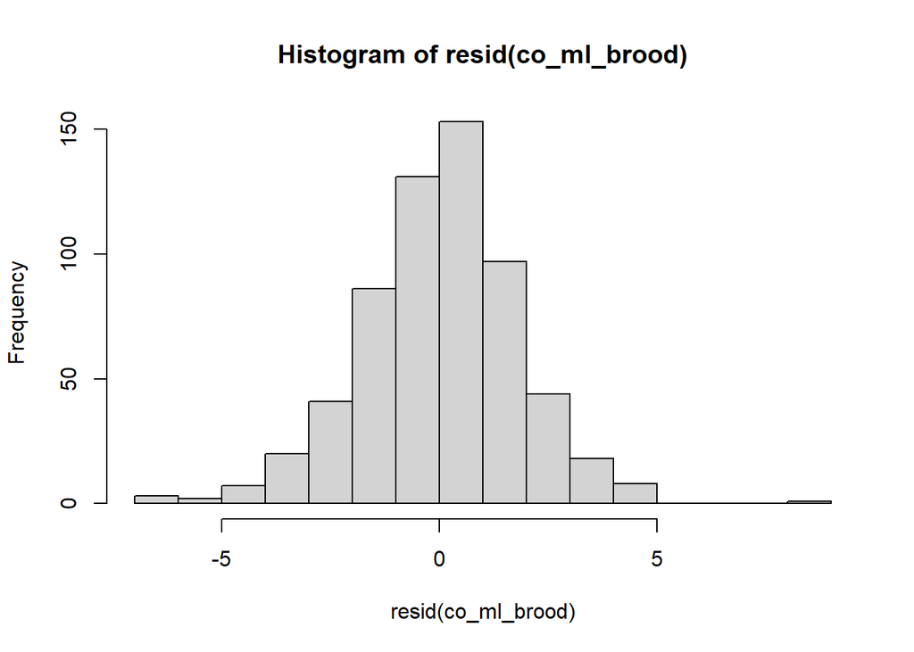

```r
hist(resid(co_ml_brood))
```

Step 3: The model set is created and the age and partner age variables are linked to their quadratic counterparts. As the brooding data set is larger than the incubation data set, this action may take much longer than in the previous section.

```r
#dredge creating model set
# linking age variables to their equivalent quadratic version so they can only be discarded or retained together
dr_cmbr<-dredge(co_ml_brood, subset = (dc(age_sc, age_sq_sc) &&
                                       dc(p_age_sc, p_age_sq_sc) &&
                                       dc(age_sq_sc, age_sc) &&
                                       dc(p_age_sq_sc, p_age_sc)))
dr_cmbr # view full model list
```

Step 4: Model selection of those delta < 2

```r
sub_m1_brood<-subset(dr_cmbr, delta<2) ##subsets models delta <2
no_m1_brood<-dim(as.data.frame(sub_m1_brood))[1] # how many models are in the subsetted model
no_m1_brood
```

```
## [1] 10
```

Step 5: Nested models are removed.

```r
nest_m1_brood <- subset(sub_m1_brood, !nested(.))# remove nested models
nest_m1_brood
```

```
## Global model call: lmer(formula = no_hours_sqrt ~ sex + pers_sc + p_pers_sc + age_sc +
##     age_sq_sc + p_age_sc + p_age_sq_sc + num_days_sc + new_part +
##     ppb_ave_diff_sc + age_sc:pers_sc + age_sq_sc:pers_sc + age_sc:ppb_ave_diff_sc +
##     age_sq_sc:ppb_ave_diff_sc + pers_sc:ppb_ave_diff_sc + new_part:ppb_ave_diff_sc +
##     p_age_sc:p_pers_sc + p_age_sq_sc:p_pers_sc + p_age_sc:ppb_ave_diff_sc +
##     p_age_sq_sc:ppb_ave_diff_sc + p_pers_sc:ppb_ave_diff_sc +
##     (1 | cycle) + (1 + ppb_ave_diff_sc | cycle_pair), data = brood_new2,
##     REML = FALSE, control = lmerControl(optimizer = "optimx",
##         optCtrl = list(method = "nlminb")), na.action = na.fail)
## ---
## Model selection table
##     (Int) new_prt num_dys_sc p_prs_sc  prs_sc ppb_ave_dff_sc sex df    logLik
## 973 8.041       +    -0.2262  -0.2617 -0.3612         0.1371   + 12 -1275.030
## 969 8.113            -0.2168  -0.2569 -0.3549         0.1394   + 11 -1276.547
## 717 8.041       +    -0.2514  -0.2605 -0.3608                  + 11 -1276.593
##       AICc delta weight
## 973 2574.6  0.00  0.452
## 969 2575.5  0.95  0.281
## 717 2575.6  1.05  0.268
## Models ranked by AICc(x)
## Random terms (all models):
## '1 | cycle', '1 + ppb_ave_diff_sc | cycle_pair'
```

```r
no_m12_brood<-dim(as.data.frame(nest_m1_brood))[1] # how many models when when nested models removed
no_m12_brood
```

```
## [1] 3
```

Step 6: Final coefficient table created via model averaging.

```r
modavm1_brood<-model.avg(nest_m1_brood, delta<2, fit = TRUE) # model averaging
modavm1_brood
```

```
##
## Call:
## model.avg(object = get.models(object = nest_m1_brood, subset = delta <
##     2))
##
## Component models:
## '123456' '23456'  '12346'
##
## Coefficients:
##        (Intercept) new_part1 num_days_sc  p_pers_sc    pers_sc ppb_ave_diff_sc
## full      8.061423 0.4135819  -0.2303143 -0.2600315 -0.3593018       0.1010101
## subset    8.061423 0.5748336  -0.2303143 -0.2600315 -0.3593018       0.1379578
##           sexMale
## full   -0.3483413
## subset -0.3483413
```

```r
Weights(modavm1_brood)
```

```
## AICc model weights
## [1] 0.452 0.281 0.268
```

```r
tablem1a_brood<-coefTable(modavm1_brood, full=TRUE)
tablem1a_brood # final coefficients table
```

```
##                 Estimate Std. Error
## (Intercept)      8.06142     0.1905
## new_part1        0.41358     0.3760
## num_days_sc     -0.23031     0.0803
## p_pers_sc       -0.26003     0.1019
## pers_sc         -0.35930     0.1022
## ppb_ave_diff_sc  0.10101     0.0900
## sexMale         -0.34834     0.1695
```

The variables listed above are highlighted as the most influential on the response variable following model averaging.